Derde beweging · Verschil onthechten

# Hoofdstuk 10 — En hij buigt

Logistische regressie: kansen, odds en odds ratio’s

> **Schets v2 — het slot van deel 1.** H9 eindigt op *“alles was al die tijd één model”*; dit hoofdstuk komt dáárna en is een **coda**: hij mag één ding doen dat H9 niet deed — laten zien dat de ruggengraat *buigt* — en dat is genoeg. Registerbewaking: niets in H10 mag harder klinken dan H9 §6.

> **De dragende lijn van v2 (Bens wens, 20-7): multiplicatief is de motor, niet de bijvangst.** De boog: de kraai stelt een vraag met twee antwoorden → de rechte lijn loopt stuk *omdat hij optelt* (optellen kent geen muur — vandaar 1.269) → het model mag geen ja zeggen, alleen een kans → kansen-wereld blijkt een keer-wereld (odds; verdubbelen en halveren zoveel je wilt, nooit onder nul) → de logaritme als adapter die van keer weer plus maakt, zodat de optel-machine van negen hoofdstukken ongewijzigd kan blijven draaien → coëfficiënten lezen in keer-taal (*OR*) → schatten primair → de rekening van het hakken, in één toetsfamilie → hij buigt. **Bib-eerst uitgevoerd**, atomen benoemd in de open punten.

> **Wat dit hoofdstuk NIET doet** (harde rem): Poisson, multinomiaal, ordinaal — deel 2. Ook niet: maximum likelihood als machinerie, pseudo-*R*², ROC/AUC, classificatietabellen, de LR-toets naast de Wald-toets, de polynoom-als-tussenstap (bewust: een polynoom kent óók geen muren — die ladder leeft in de oefenboek-schil).

## 1. De nacht van de kraai

Verhaal-stem, herschreven 20-7 na Bens leesronde. Twee reparaties: (1) de scène hield zijn eigen regel achter — de kraai selecteert op wat het licht terugkaatst, niet op wat een steen waard is; die regel is nu één keer zichtbaar gemaakt (“Er kwam iets terug, of er kwam niets terug”) zónder uitleg; (2) “Hij zag ze heel goed” had een vaag voornaamwoord — verankerd op de stenen die hij liet liggen. En de scène mag geen ijzeren wet suggereren: er staat nu expliciet één glimmende steen die hij overslaat en één doffe die hij oppakt (Hans/Dora, ongenoemd) — anders was er straks geen kans-model nodig. Wilde-regel verhaal-stem: verlies mag, ironie nooit. GEEN statistiek.

**Verhaal-consistentie, Bens call:** deze scène speelt de nacht vóór de diefstal van H4. De kraai pakt er zes óp en legt ze terug; Geer neemt hij later pas echt mee. Zo blijft het kistje van H1–H9 intact (n = 12 overal) en is *gepakt* geen diefstal maar een oordeel.

De kraai kwam toen iedereen sliep.

De twaalf lagen op een rij op het mos, zoals ze daar sinds de vondst lagen, en de maan stond laag. De kraai liep de rij langs zoals hij alles langsliep: één stap, kop schuin, één stap.

Hij keek niet zoals de olifant keek, die alles zag en alles bewaarde. Hij hield zijn kop scheef en wachtte af wat het maanlicht terugdeed. Wat een steen wáárd was — hoe zwaar, hoe oud, hoe lang hij op de bodem van een meer had gelegen — daar vroeg hij niet naar. Er kwam iets terug, of er kwam niets terug.

Bij de eerste steen bleef hij lang staan. Toen pakte hij hem op, hield hem even vast, en legde hem terug.

Zo ging het de rij af. Sommige stenen liet hij liggen, en het was niet dat hij die stenen niet zag; hij zag ze heel goed. Hij zag dat er eentje zwaar was en oud, en dat er onderin iets moois zat, op de plek waar het maanlicht niet kon komen. Hij liep door.

En één keer, ergens halverwege de rij, deed hij het andersom. Hij stond bij een steen die het licht keurig terugstuurde, wipte van zijn ene poot op de andere — en liep door. Drie stenen verder pakte hij er een op die nauwelijks glansde. Waarom, dat wist alleen de kraai, en misschien wist hij het zelf ook niet.

Bij de zesde die hij oppakte was de maan al gezakt.

Hij kende geen woorden voor wat hij deed. Hij had geen lijstje in zijn kop met eigenschappen, en hij woog niets af. Er was alleen dat ene moment, telkens weer, waarin het lijf van de kraai besloot: oppakken. Of doorlopen.

En de stenen — de stenen wisten van niets. Ze lagen daar met hun gewicht en hun slijpsel en hun scheurtjes en hun namen, en van alles wat ze waren kwam er die nacht maar één ding aan.

Ja. Of nee.

Ja of nee. Daar kunnen we het over hebben.

Want kijk wat er met deze twaalf stenen gebeurd is. Negen hoofdstukken lang heb ik je geleerd om precies te zijn. Karaat tot op de tiende. Glans op een schaal van nul tot honderd. Gladheid, merk. We hebben van Kees uitgerekend hoeveel glans hij tekortkomt, tot achter de komma, en we hebben het nog eens overgedaan met een derde kolom erbij omdat het eerste antwoord te grof was. En dan komt er één kraai langs en van dat hele bouwwerk blijft één bit over.

Dat is niet de kraai die dom doet. Dat is de wereld. Zoek de resultaten-sectie van je vak op en tel mee: hersteld of niet. Terugval of niet. Uitgevallen of niet. Aangenomen, geslaagd, overleden, opnieuw opgenomen. De helft van alles waar mensen onderzoek naar doen heeft maar twee gedaanten, en dat is precies de helft waar dit boek tot nu toe niets over gezegd heeft.

Dus dat gaan we nu doen. En ik zeg het maar meteen, want het is het enige wat je van dit hoofdstuk hoeft te onthouden als je de rest vergeet: **dit is geen nieuwe statistiek.** Het is de regel van hoofdstuk 9, hetzelfde rechthoekje, dezelfde motor — met één ding ertussen. Aan het eind van het vorige hoofdstuk zei ik dat er geen techniek meer bij komt. Dat was waar. Er komt geen techniek bij; er komt een *knik* bij. De ruggengraat waar dit boek naar vernoemd is krijgt hier zijn laatste eigenschap, en het is de eigenschap die van een stapel botten een ruggengraat maakt.

Hij buigt.

## 2. De lijn loopt stuk

Laten we het gewoon proberen. Dat is niet retorisch bedoeld — ik meen het: probeer het, want de manier waarop het misgaat is het halve hoofdstuk.

We hebben een kolom die twaalf keer een nul of een één is. Ik noem hem *gepakt*: één als de kraai de steen die nacht opgepakt heeft, nul als hij doorliep. Zes keer een één, zes keer een nul. En we hebben een voorspeller waarvan je bij een kraai wel iets vermoedt: glans.

**Tabel 10.1.** *De twaalf, gesorteerd op glans, met het oordeel van de kraai.*

| *naam* | *karaat* | *glans* | *gepakt (0/1)* |
| --- | --- | --- | --- |
| Anna | 0.4 | 20 | 0 |
| Bram | 0.5 | 30 | 0 |
| Cees | 0.5 | 30 | 0 |
| Dora | 0.7 | 30 | 1 |
| Kees | 1.5 | 30 | 0 |
| Else | 1.0 | 50 | 0 |
| Leen | 1.5 | 50 | 1 |
| Hans | 1.2 | 60 | 0 |
| Faas | 1.0 | 70 | 1 |
| Ida | 1.3 | 70 | 1 |
| Geer | 1.1 | 80 | 1 |
| Joop | 1.3 | 80 | 1 |

Zet ze op glans gesorteerd en je ziet het zonder rekenen: onderin vooral nullen, bovenin alleen maar enen, en in het midden een rommeltje. Dora is opgepakt en Hans niet, en Hans glanst het dubbele van Dora. Precies wat je van een kraai verwacht — een neiging, geen wet. Kees, voor wie het nog bijhoudt: glans 30, niet gepakt. Zijn anderhalve karaat heeft hem bij de kraai niets gebracht.

Dus doen we wat we sinds hoofdstuk 4 doen — we leggen er een lijn doorheen. De computer rekent de rechthoekjes en geeft:

$$\widehat{\text{gepakt}}_i = -0.269 + 0.01538 \times \text{glans}_i \tag{10.1}$$

En dat wérkt, in zekere zin. Vul glans 50 in: $0.01538 \times 50 = 0.769$, min $0.269$ is $0.500$. Dat leest als een kans, en dat is ook precies wat het is: het gemiddelde van een kolom nullen en enen ís een kans — dat wisten we al in hoofdstuk 8, toen we dummies gingen voorspellen; alleen zat de dummy toen aan de andere kant van het isgelijkteken.

Vul nu glans 100 in.

$$-0.269 + 0.01538 \times 100 = 1.269$$

Een kans van 1.269. De kraai pakt hem op met een waarschijnlijkheid van honderdzevenentwintig procent. En de andere kant op is het net zo erg: een volmaakt doffe steen, glans 0, krijgt van dit model een kans van **−0.269**. Minder dan onmogelijk, wat dat ook zou moeten zijn.

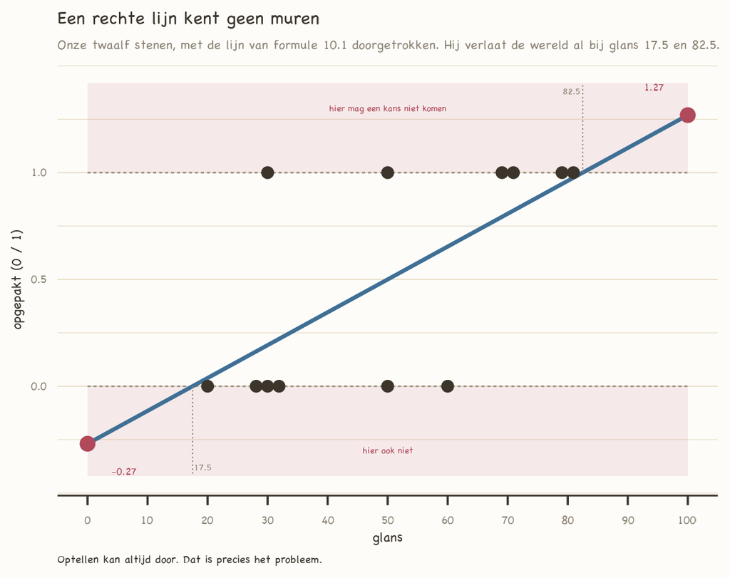

Nu kun je hier schouderophalend langslopen — “ja, buiten het bereik van je data moet je niets voorspellen” — en dat is ook waar, maar het is de verkeerde les. Kijk waar de lijn de nul kruist: bij glans 17.5. En de één: bij glans 82.5. Onze allerdofste steen heeft glans 20 en onze felste 80. Het model staat dus niet ergens in een verre uithoek onzin te verkondigen; het staat op nog geen drie glanspunten van Anna en op tweeënhalf van Joop op het punt de wereld te verlaten.

En nu de echte diagnose, want die is belangrijker dan het symptoom. De lijn loopt niet stuk omdat hij te lang is. Hij loopt stuk om wat hij *doet*. Een rechte lijn is een optel-machine — hoofdstuk 4 zei het al, en ik vond het toen al een heerlijk woord: lineaire regressie is een *additieve* methode. Per glanspunt komt er 0.01538 bij. Per tien punten: 0.154 erbij. Altijd hetzelfde erbij, waar je ook staat. En optellen kent geen muur. Er bestaat geen getal waarbij “erbij” ophoudt te werken. Bij glans 82.5 staat de teller op één — vol, zekerder kan niet — en de lijn merkt het niet eens. Hij doet er gewoon weer 0.154 bij. Zo kom je aan 1.269: niet door pech, maar omdat je een gereedschap dat eindeloos kan optellen hebt losgelaten op een vraag waarvan het antwoord tussen twee muren woont.

Onthoud die diagnose. Niet “de lijn is te steil” of “de data te smal” — **optellen kent geen muur.** De rest van dit hoofdstuk is niets anders dan de zoektocht naar een bewerking die wél muren respecteert.

## 3. Het model mag geen ja zeggen

Voor we gaan repareren, eerst een vraag die belangrijker is dan de reparatie. Wát moet dit model eigenlijk voorspellen?

De verleiding is: ja of nee. Het model kijkt naar de glans en zegt “opgepakt” of “doorgelopen”, en dan tellen we hoe vaak het goed zat. Dat voelt eerlijk — je vraagt een ja/nee-vraag, je krijgt een ja/nee-antwoord.

Maar kijk eens naar twee stenen uit ons kistje.

Else heeft glans 50. Leen heeft glans 50.

De kraai pakte Leen op. Else liet hij liggen.

Wat moet het model nu zeggen als je hem glans 50 voedt? Ja is fout. Nee is fout. Elk stellig antwoord is aantoonbaar, in ons eigen kistje, in de helft van de gevallen mis. Het énige antwoord dat niet gelogen is, is: *ongeveer de helft.*

En daarmee heb je de belangrijkste zin van dit hoofdstuk al te pakken, dus ik zet hem apart:

> Een model over een ja/nee-uitkomst voorspelt geen ja of nee. Het voorspelt een kans.

Dat is niet het model dat zich eruit draait. Dat is het model dat precies weet wat het wel en niet weet. Kijk terug naar hoofdstuk 1: het gemiddelde was de beste gok voor een steen die je nog niet gezien had, en de standaardafwijking zei hoe ver je er gemiddeld naast zou zitten. De gok was nooit een belofte. Hier is het niet anders, alleen ziet de gok er anders uit: bij een getal gok je een getal met een marge, bij een ja/nee gok je een verhouding.

En hier valt de derde steen van dit boek op zijn plek. Else, de gemiddelde diamant, die in hoofdstuk 1 op precies het gemiddelde lag en daardoor onzichtbaar was — geen vierkantje, geen rechthoekje, nergens een bijdrage. In hoofdstuk 7 bleek ze op gladheid níét gemiddeld te zijn, en werd ze zichtbaar zodra we beter keken. En vannacht was ze weer op een nieuwe manier onmogelijk: **op een ja/nee kan niemand gemiddeld zijn.** Er is geen halve keer opgepakt. Elke steen deed één van de twee dingen, helemaal, en het gemiddelde van de zes enen en zes nullen — 0.50 — is een getal dat geen enkele steen zelf heeft gehad.

Dat is de tweede helft van wat een kans is, en de reden dat kansen zo moeilijk uit te leggen zijn. De kans woont niet in de steen. Hij woont in de verzameling stenen waar hij op lijkt.

Else-boog, derde beat (H1 onzichtbaar op het gemiddelde → H7 “Else staat niet op het gemiddelde”, r271 aldaar — die beat bestáát, maar staat in H7 als [voorstel]; guard j blijft dus staan tot Bens akkoord op de Else-boog. Belofte-boekhouding: dit is een oogst, geen aankondiging — Else is in H1 bewust zónder “onthoud haar” achtergelaten (keuzes §7b).

“De kans woont niet in de steen” is een **epigram-kandidaat** en concurreert met “als de wereld je een getal geeft, hak het niet doormidden” (§7). Twee kandidaten, Bens call. Quine mag hier onuitgesproken meelopen (wat betékent een kans voor één ding?); niet uitleggen.

## 4. Van plus naar keer

Goed. Het model moet een kans voorspellen, en een kans zit klem tussen twee muren: nul en één. Onze motor is een optel-machine, en optellen kent geen muur. Dat is het hele conflict, in twee zinnen.

Eén reparatie kun je zelf verzinnen, dus laten we die eerst afvoeren. Je knijpt de lijn gewoon af: alles boven de één maak je één, alles onder de nul maak je nul.

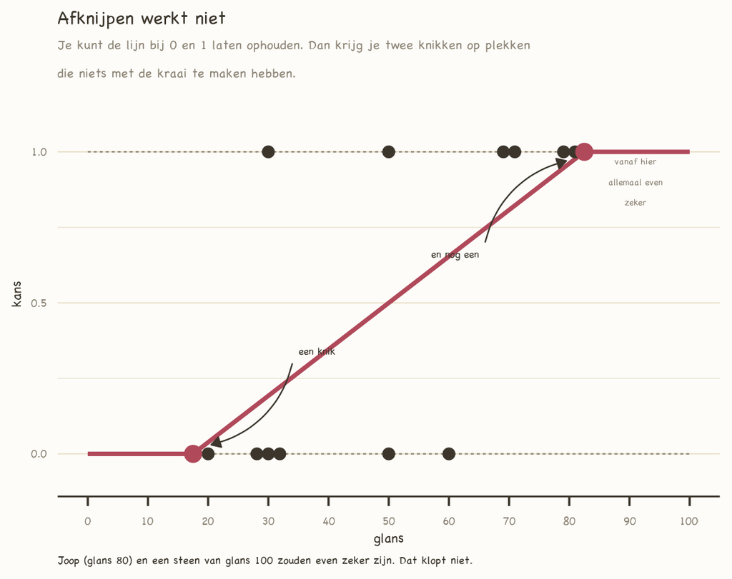

Kijk er even goed naar, want het is leerzamer dan het lijkt. Je krijgt twee knikken, op glans 17.5 en 82.5 — plekken die uit de rekensom komen en niets met de kraai te maken hebben. En rechts van de tweede knik is álles even zeker: Joop met zijn glans 80 en een denkbeeldige steen van glans 100 krijgen exact dezelfde kans, want het platte stuk is plat. Dat is pertinent onzin — en let op wat je eigenlijk gedaan hebt. Je hebt het optellen niet gerepareerd; je hebt het alleen verboden voorbij een hek. Binnen het hek telt de machine nog precies zo door als eerst, en op het hek zelf houdt de wereld abrupt op met bewegen. De diagnose van paragraaf 2 staat nog fier overeind.

Wat we nodig hebben is geen kortere lijn en geen hek. We hebben een andere *bewerking* nodig. Niet erbij. **Keer.**

Dat gaat in twee stapjes, en het eerste stapje beginnen we waar we altijd beginnen: bij de kans, want dat is het enige getal in dit hoofdstuk waar je al gevoel voor hebt.

### Stap één: van kans naar odds

**odds**  
*odds*  
$\text{kans} / (1 - \text{kans})$  
De kans op het één, gedeeld door de kans op het ander. “Vier staat tot één.”

Stel dat de kans dat de kraai een steen oppakt 0.80 is. Dan is de kans dat hij doorloopt 0.20 — die volgt vanzelf, één min de kans. De **odds** zijn die twee kansen, door elkaar gedeeld:

$$\frac{0.80}{0.20} = 4$$

Vier. Lees het als *“vier staat tot één”*: op elke vier keer oppakken één keer doorlopen. En doe nu het grensgeval: kans 0.50. Dan staat er $0.50 / 0.50 = 1$ — precies fifty-fifty betekent odds van één op één. Zit de kans daaronder, dan zakken de odds onder de één: kans 0.20 geeft $0.20 / 0.80 = 0.25$. De kans op oppakken is dan 0.25 keer zo groot als de kans op doorlopen — kleiner dus, en als dat duizelt zet je er gewoon “staat tot 1” achter: 0.25 staat tot 1.

In formule, en dit is de hele formule:

$$\text{odds} = \frac{\pi}{1 - \pi} \tag{10.2}$$

waarin $\pi$ de kans is dat het gebeurt. Odds is geen nieuw soort onzekerheid; het is dezelfde informatie als de kans, in een andere taal — de taal van de bookmaker in plaats van die van de kansrekenaar.

Kijk nu wat er met de muren gebeurt, want dáárom staan we hier. De bovenmuur eerst. Kans 0.5 → odds 1. Kans 0.9 → odds 9. Kans 0.99 → odds 99. Kans 0.999 → odds 999. De odds lopen gewoon door, zo hoog als de kans maar wil kruipen: **de muur bij één is weg.** En de ondermuur? Die staat er nog — maar kijk hoe hij zich gedraagt. Kans 0.05 geeft odds 0.0526. Kleinere kans, kleinere odds: 0.01, 0.001, 0.0001 — de odds worden piepklein, maar ze blijven positief. Altijd.

En een getal dat alleen maar positief hoeft te blijven, dát is een getal waar *keer* mee overweg kan. Halveer maar eens iets, en blijf halveren: 1, 0.5, 0.25, 0.125, 0.0625 — je kunt dit tot sint-juttemis volhouden en je duikt nooit onder nul. Waar optellen dwars door elke muur heen marcheert, respecteert vermenigvuldigen de nul uit zichzelf. Gratis. Zonder hek.

Dus zó moet ons model in de kansen-wereld werken: niet per glanspunt iets *erbij* (dat liep stuk), maar per glanspunt *keer* een vast getal. Odds omhoog: keer. Odds omlaag: keer een getal onder de één. Waar lineair zich additief gedraagt, gedraagt deze wereld zich multiplicatief — en ik zeg je er eerlijk bij dat ik dit het mooiste moment van het hoofdstuk vind. Optellen is netjes en betrouwbaar en een tikje saai. Op het moment dat je multiplicatief gaat denken, verandert er echt iets in je hoofd. Dit boek doet dat hier voor het eerst.

### Stap twee: de adapter

Maar nu hebben we een probleem dat je misschien al zag aankomen. Onze motor — negen hoofdstukken oud, net tot ruggengraat gekroond — is en blijft een optel-machine. $b_0 + b_1 X$: startpunt, en per eenheid iets erbij. Die machine gaan we niet ombouwen; het hele punt van dit hoofdstuk is dat hij *niet vervangen wordt*. Dus we hebben iets nodig dat tussen de optel-machine en de keer-wereld in staat en de twee talen in elkaar overzet. Een adapter.

Die adapter bestaat, en hij heet de **logaritme**. Je hoeft er hier maar één ding van te weten, en dat ding kun je narekenen op je telefoon:

$$\ln(2 \times 3) = \ln(2) + \ln(3)$$

Reken maar na: $\ln(2) = 0.69$ en $\ln(3) = 1.10$, samen $1.79$. En $\ln(6)$? Ook $1.79$. **De logaritme maakt van keer plus.** Wat in de odds-wereld een vermenigvuldiging is, is in de log-wereld een optelling — en optellen, dát kan onze machine.

$\ln$ is de *natuurlijke logaritme*, de omkering van “$e$ tot de macht” — met $e$ dat gekke getalletje 2.718 dat je rekenmachine als $e^x$ kent. Drie ankerpunten: $\ln(1) = 0$ (het grensgeval komt op nul te liggen), getallen boven 1 worden positief ($\ln(3) = 1.10$), getallen tussen 0 en 1 worden negatief ($\ln(\tfrac{1}{3}) = -1.10$) — netjes symmetrisch rond de één.

Neem dus de logaritme van de odds — de **log-odds**, en het deftige woord is de **logit**:

$$\text{logit}(\pi) = \ln\!\left(\frac{\pi}{1 - \pi}\right) \tag{10.3}$$

Kans 0.5 wordt 0. Kans 0.9 wordt +2.20, kans 0.99 wordt +4.60, en het houdt niet op. Kans 0.1 wordt −2.20, kans 0.01 wordt −4.60, en ook dat houdt niet op. De kans zat klem tussen twee muren; de log-odds loopt van min oneindig tot plus oneindig, met in het midden — waar het fifty-fifty is — keurig een nul.

En dáár, in die muurloze wereld, mag onze rechte lijn weer gewoon een rechte lijn zijn:

$$\ln\!\left(\frac{\pi_i}{1 - \pi_i}\right) = b_0 + b_1 X_i \tag{10.4}$$

Kijk daar even naar en zie wat er níét gebeurd is. Rechts van het isgelijkteken staat exact wat er in hoofdstuk 4 stond. Exact wat er in hoofdstuk 7 stond met meer termen, in hoofdstuk 8 met een dummy, in hoofdstuk 9 met een product-kolom. Geen nieuwe motor, geen nieuwe rechthoekjes, geen nieuwe manier van denken. Er is alleen links iets veranderd: niet de uitkomst zelf staat daar, maar een *bewerking* van de uitkomst.

Die bewerking heet de **link**. Zij verbindt de wereld waarin je vraag leeft — een keer-wereld met muren — met de wereld waarin je model leeft, een optel-wereld zonder muren. Het model buigt niet omdat wij het krom hebben gemaakt. Het model is nog steeds kaarsrecht; wij hebben er alleen een vertaler tussen gezet.

**link-functie**  
*link function*  
ook: de vertaler

De link vertaalt de uitkomst naar de schaal waarop het model recht is. Bij een ja/nee-uitkomst is dat de logit — in formulevorm $g(\pi) = b_0 + b_1X$, waarbij die $g$ niets anders is dan “reken eerst even om”. Andere soorten uitkomsten hebben andere vertalers, en die komen in deel 2 langs.

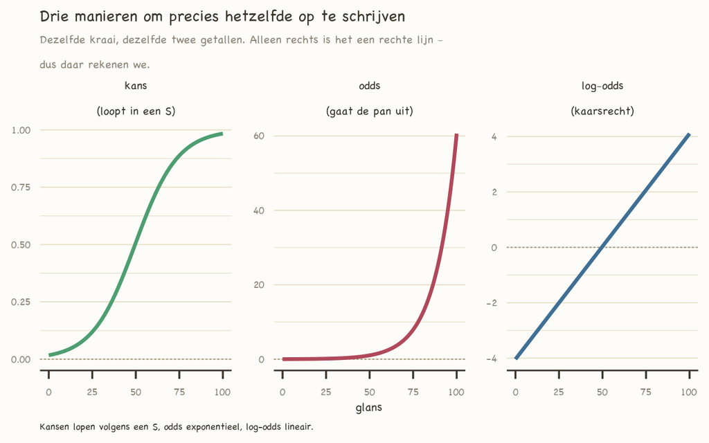

Eén figuur, drie gedaanten van precies hetzelfde model. Rechts de log-odds: kaarsrecht, de optel-machine op zijn eigen terrein. In het midden de odds: de pan uit, want elke stap naar rechts is een vermenigvuldiging — dat is hoe exponentiële groei eruitziet. En links de kans: een S-bocht, onderaan platgedrukt tegen de nul, bovenaan tegen de één, in het midden op zijn steilst. Die S is geen vormpje dat iemand mooi vond. Het is een rechte lijn, bekeken door de vertaling heen.

En de terugweg — van de rechte lijn naar de kans — kan altijd, en levert altijd een echte kans op. Want terugvertalen gaat met “$e$ tot de macht”, en **$e$ tot de macht wat-dan-ook is nooit negatief**. Kijk maar, dit is geen stelling maar een rijtje om even langs te lopen: $e^{2.48} = 11.9$. $e^{0} = 1$. $e^{-2.41} = 0.09$. $e^{-10} = 0.000045$. Hoe negatiever de macht, hoe kleiner het getal — maar het duikt nóóit onder nul. Wat de lijn ook beweert, hoe diep hij ook afdaalt, de odds die eruit terugrollen zijn positief, en een positieve odds geeft een kans tussen nul en één:

$$\pi_i = \frac{\text{odds}_i}{1 + \text{odds}_i} \tag{10.5}$$

Deel een positief getal door datzelfde getal plus één, en je zit gegarandeerd tussen de nul en de één. **De multiplicatieve structuur is precies wat het model binnen de wereld houdt.** De rechte lijn van hoofdstuk 4 liep stuk omdat optellen geen muur kent; odds kun je eindeloos verdubbelen en eindeloos halveren zonder ooit de wereld te verlaten. Dát is de reparatie — niet een krommere lijn, maar een andere bewerking.

**Voor wie verder wil — de logistische functie, en waarom $e$.** Schrijf formule 10.4 en 10.5 in elkaar en je krijgt de *logistische functie*, het ding waar de hele techniek naar vernoemd is:

$$\pi_i = \frac{e^{\,b_0 + b_1 X_i}}{1 + e^{\,b_0 + b_1 X_i}} = \frac{1}{1 + e^{-(b_0 + b_1 X_i)}}$$

Waarom $e$, en niet 2 of 10? Elke basis zou wérken — je krijgt dezelfde S, alleen met andere getallen op de helling. Maar $e$ is de basis waarin groei en helling elkaars spiegelbeeld zijn (de functie $e^x$ is de enige die op elk punt precies zo snel groeit als hij hoog is), en dat betaalt zich hier concreet uit: op het steilste punt van de S is de helling in kansen exact $b/4$ — de vuistregel die je in paragraaf 5 gaat gebruiken. Met basis 10 zou daar een lelijk omrekengetal staan.

En waarom niet gewoon een kromme lijn — een polynoom, $b_0 + b_1X + b_2X^2$? Omdat krommer het probleem niet is. Een polynoom buigt prachtig, maar hij blijft een optel-machine, en optellen kent geen muur: elke polynoom schiet uiteindelijk naar plus of min oneindig en verlaat de wereld alsnog. Je had geen andere lijn nodig. Je had een andere bewerking nodig.

## 5. Wat de getallen zeggen

Nu de kraai. De computer zoekt de $b$’s die het best bij onze twaalf stenen passen — niet meer met de kleinste-kwadraten-som van hoofdstuk 4, maar met een broertje ervan dat op nullen en enen werkt; hoe dat broertje zoekt hoort in het oefenboek, wát er uit komt hoort hier:

$$\ln\!\left(\frac{\hat{p}_i}{1 - \hat{p}_i}\right) = -4.04 + 0.0814 \times \text{glans}_i \tag{10.6}$$

(Het dakje op de $p$ zegt wat dakjes altijd zeggen: geschat.)

Dat getal, 0.0814, is de helling. En het is een correct en volstrekt onbruikbaar getal: één glanspunt erbij, en de log-odds stijgt met 0.0814. Niemand voelt log-odds. Ik ook niet. Dus doen we wat ik in de bijles ook altijd doe als de logit begint te zweven: we rekenen eerst gewoon een paar kansen uit, want de kans is het enige getal hier dat niet vaag is.

Neem Anna, glans 20. Invullen: $-4.04 + 0.0814 \times 20 = -4.04 + 1.63 = -2.41$. Dat is haar log-odds. Terug naar odds: $e^{-2.41} = 0.090$. En van odds naar kans met formule 10.5: $0.090 / 1.090 = .08$. De kraai pakt Anna op met een kans van .08 — eens in de twaalf nachten, zegt het model.

Doe dat voor de hele glans-lijn, in stappen van tien, en zet de drie talen naast elkaar:

| glans | log-odds | odds | kans |
| --- | --- | --- | --- |
| 20 | −2.41 | 0.090 | .08 |
| 30 | −1.59 | 0.203 | .17 |
| 40 | −0.78 | 0.458 | .31 |
| 50 | 0.03 | 1.034 | .51 |
| 60 | 0.85 | 2.334 | .70 |
| 70 | 1.66 | 5.270 | .84 |
| 80 | 2.48 | 11.897 | .92 |

Deze tabel is het hele hoofdstuk in zeven regels, dus we lezen hem kolom voor kolom.

**De log-odds-kolom** is de optel-machine: telkens 0.814 erbij (afgerond zie je 0.81 of 0.82 staan — kruimels). Gelijke stappen, een rechte lijn, hoofdstuk 4 in een nieuwe jas.

**De odds-kolom** — en nu ga je iets doen wat ik mijn studenten ook altijd laat doen, dus pak je rekenmachine erbij. Ik wil weten met welk getal je de odds bij glans 50 moet vermenigvuldigen om de odds bij glans 60 te krijgen. Deel ze op elkaar: $2.334 / 1.034 = 2.26$. Doe het nog eens, ergens anders in de kolom — van 70 naar 80: $11.897 / 5.270 = 2.26$. Altijd hetzelfde getal. Wil je van een odds naar de odds één stap verderop, dan vermenigvuldig je met 2.26. Klaar. En dat vaste vermenigvuldigingsgetal heet de **odds ratio**.

**odds ratio**  
*odds ratio* (*OR*)  
$e^{b}$  
Het vaste getal waarmee de odds vermenigvuldigd wordt bij één stap in de voorspeller. *OR* = 1: er verandert niets. Boven 1: opwaarts. Onder 1: neerwaarts.

Waar komt die 2.26 vandaan? Uit de adapter, maar nu de andere kant op. De logaritme maakte van keer plus; $e$ tot de macht maakt van plus weer keer. In de log-odds-kolom komt er per tien glanspunten 0.814 *bij*; in de odds-kolom betekent dat *keer* $e^{0.814} = 2.26$. En per één glanspunt: keer $e^{0.0814} = 1.085$. Let wel: dat tarief werkt in keer, niet in plus — tien stapjes van keer 1.085 is keer $1.085^{10} = 2.26$, niet keer 1.85. Vermenigvuldigingen stapelen als machten, niet als sommen. Dat is even wennen en dan is het heerlijk.

**Elke tien glanspunten meer dan verdubbelt de odds dat de kraai hem oppakt.** Dat is een zin die je aan tafel kunt zeggen, en het is het getal dat je in artikelen ziet staan — meestal als *OR*, met een betrouwbaarheidsinterval erachter. Herken het stramien van hoofdstuk 4: dit is wéér een tarief, net als 32.1 glans per karaat. Alleen was dat tarief een optelbedrag, en dit is een keer-getal. Verschil per verschil — maar dan multiplicatief.

En noteer meteen de strik die eronder ligt. In alle voorgaande hoofdstukken was **nul** het getal dat “er gebeurt niets” betekende: een $b$ van nul, een $r$ van nul, een verschil van nul. In de keer-taal is dat **één**, want keer één laat alles zoals het was. Geen nieuwe regel, dezelfde regel door de adapter gehaald: $e^0 = 1$ — de nul van de optel-wereld ís de één van de keer-wereld. Raak je dat kwijt, dan lees je elk artikel in je vak verkeerd; een *OR* van 0.98 is bijna niks, geen bijna-nul.

### De helling is niet overal even steil

Nu **de kans-kolom**, en daar wacht het lastigste van logistische regressie, en tegelijk het mooiste.

Bij de regressie van hoofdstuk 4 was $b$ een belofte die overal gold: één karaat erbij is 32.1 glans erbij, of je nu onderaan of bovenaan de wolk zit. Kijk nu naar de kansen. Van glans 20 naar 30 stijgt de kans 9 punten. Van 40 naar 50: 20 punten. Van 70 naar 80: 8 punten. Zelfde stap in glans, drie verschillende antwoorden — er bestáát geen vast kans-tarief. Dat kan ook niet: een curve die tegen de nul en de één wordt platgedrukt, moet daar wel vlakker lopen. Constant is alleen de vermenigvuldiging in de odds. De keer-taal is de enige taal waarin dit model overal hetzelfde zegt.

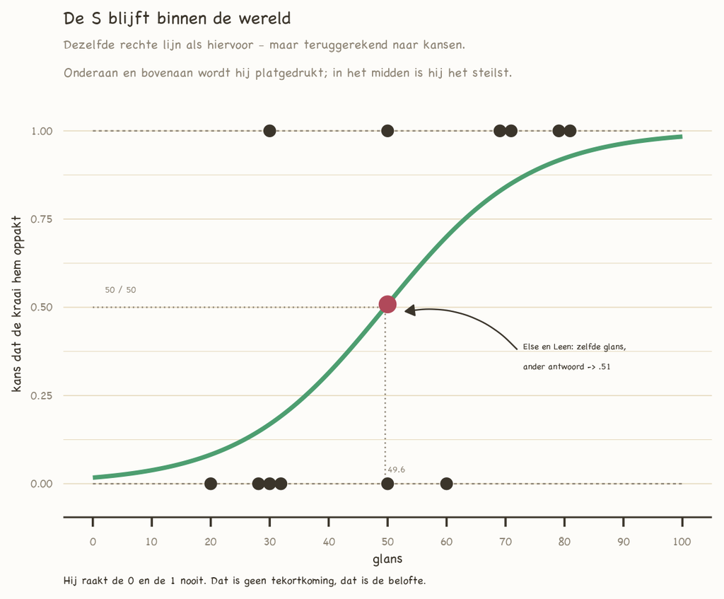

En dat is geen slordigheid van het model — het model zegt iets wat je al wist voordat je het vroeg: **bij een steen die toch al bijna zeker opgepakt wordt, maakt extra glans nauwelijks meer uit.** Bij een steen die het niet weet, maakt het alles uit. In het midden van de S telt elke glanspunt; tegen de muren aan is de wedstrijd al gelopen.

Eén vuistregel nog, want die is te bruikbaar om achter te houden. Op het steilste punt van de bocht — waar de kans 0.5 is — is de helling in kansen ongeveer een kwart van $b$. Bij ons: $0.0814 / 4 = 0.020$, dus zo’n twee procentpunt kans per glanspunt, twintig per tien punten. Kijk in de tabel: van 50 naar 60 gaat de kans van .51 naar .70. Negentien punten. De vuistregel klopt, en hij klopt alléén daar — aan de randen overschat hij schromelijk. Precies goed: hij is bedoeld om een *OR* snel menselijk te maken, niet om het model te vervangen.

### En waar ligt het omslagpunt?

Nog één getal dat je zo uit de formule vist, en het is het getal dat een lezer meestal echt wil weten: bij welke glans wordt het fifty-fifty? Dat is waar de log-odds nul is — waar de odds één is — dus:

$$X_{.50} = \frac{-b_0}{b_1} = \frac{4.04}{0.0814} = 49.6$$

Bij glans 49.6 zegt het model: munt opgooien.

En daar ligt Else, op glans 50. Ze had het niet mooier kunnen doen. Ons model geeft haar een kans van **.51** — het meest nietszeggende getal dat een model kan produceren — en dat is niet omdat het model haar niet begrijpt, maar omdat wij haar samen met Leen op de steilste plek van de bocht hebben gelegd, waar twee identieke stenen twee verschillende nachten hebben gehad. Ze zegt nog steeds niks. Ze telt nog steeds mee.

## 6. Met de handen op de rug

Je kent de volgorde inmiddels: eerst de schatting, dan pas de vraag of het echt is. En je weet ook al wat hier gaat gebeuren, want de toets is — voor het laatst, ik beloof het — geen nieuwe toets. Het is de tweede vraag van het twee-vragen-stramien uit hoofdstuk 7, gericht op de enige kolom die we hebben: voegt glans iets toe aan het voorspellen van de kraai?

De computer geeft bij $b_1 = 0.0814$ een standaardfout van 0.0427. Deel het één door het ander en je hebt je toetsingsgrootheid: 1.91. Dat getal heet hier geen *t* maar een *z* — bij dit soort modellen wordt direct tegen de klok van hoofdstuk 3 aangelegd in plaats van tegen zijn iets bredere neefje — en het levert *p* = .057.

**Dramaturgie-waarschuwing, expliciet aan Ben — ongewijzigd uit v1.** Dit is de derde net-aan in het boek: .049 (opening), .054 (slot H9), .057 (hier). Twee is een spiegel, drie is een tic. Het getal is niet gekozen maar uitgerekend: met n = 12 en een ja/nee-uitkomst loopt de Wald-*z* tegen een plafond van ~1.9, ongeacht hoe sterk het patroon wordt (sterker → volledige scheiding → SE explodeert). **Drie uitwegen, Bens call:** (a) zoals hier — de derde net-aan wordt betekenisvol gemaakt als bewijsstuk van §7 (een ja/nee kost informatie, dít is de rekening in *p*-eenheden); (b) de toets helemaal weglaten (schatten primair; maar de VIOS-lezer komt de *p* in elk artikel tegen); (c) het gestel verruimen — breekt H1–H9, praktisch uitgesloten. Bewust niet voorgesteld: de LR-toets (*p* = .018 op dezelfde data) — statistisch beter bij kleine n, maar dan moeten er twee toetsen uitgelegd, en dat is deel-2/oefenboek-materie (getal geborgd).

En dan het interval, want dat vertelt het volwassener. Het 95%-interval rond de helling loopt van −0.002 tot 0.165 in de log-odds-wereld. Zet dat om naar iets menselijks — per tien glanspunten, in de keer-taal — en er staat:

> *OR* = 2.26, 95%-BI [0.98, 5.22]

Lees dat interval hardop, want het is een oefening in twee talen tegelijk. In de optel-wereld schampt het de **nul**. In de keer-wereld schampt het de **één**. Dat zijn niet twee bevindingen; dat is één bevinding in twee jassen — en als je ooit twijfelt of je de vertaling snapt, is dit de test.

En inhoudelijk: het kán zijn dat glans niets doet voor de kraai, nét. En het kán zijn dat tien glanspunten de odds vervijfvoudigen. Dat is een breed interval, en het is breed om een reden die dit hoofdstuk zo meteen zijn hele slot geeft.

### Meer kolommen

Voor de volledigheid, en het is één alinea waard omdat het de belofte van de openingsparagraaf inlost: alles van hoofdstuk 7, 8 en 9 werkt hier onveranderd. Zet er een tweede voorspeller bij, een dummy, een product-kolom — rechts van het isgelijkteken is niets veranderd, dus er is niets te leren.

Doe het maar met karaat erbij, dan zie je meteen iets anders. De computer geeft voor karaat een $b$ van 0.40, met een standaardfout van 2.38 — een leeg adres zoals je ze in hoofdstuk 9 hebt leren herkennen, en zo leeg dat het interval in de keer-taal van bijna nul tot ver boven de honderd loopt. Twee lezingen: óf de kraai kijkt echt alleen naar glans en niet naar gewicht, óf twaalf stenen kunnen die vraag simpelweg niet beantwoorden. Ik weet het niet, en het model ook niet, en dat opschrijven is het eerlijke antwoord.

De karaat-coda blijft bewust kort en bewust *negatief* (leeg adres); derde lege adres van het boek (H7, H9) — kleine-n-realiteit, geen zwakte. v1 zei “van vier keer zo klein tot honderd keer zo groot” — dat klopte niet met het interval; nagerekend: *OR* per karaat 1.49, 95%-BI [0.014, 158], dus “van bijna nul tot ver boven de honderd”. Geborgd: `glm(gepakt ~ glans + karaat)` → b_glans = 0.0775 (*SE* = 0.0481), b_karaat = 0.397 (*SE* = 2.380, *z* = 0.17, *p* = .87).

En zo staat het in een artikel — lees maar, je kunt het nu:

> “De kans dat een steen werd opgepakt nam toe met de glans van de steen, *b* = 0.081, *SE* = 0.043, *z* = 1.91, *p* = .057; per tien glanspunten kwam dat neer op een meer dan verdubbelde odds, *OR* = 2.26, 95%-BI [0.98, 5.22]. Bij het gemiddelde glansniveau lag de geschatte kans rond .50.”

Noord-ster-oogst, H10-variant. Verzonnen alinea, waarheidsscript regenereert; descriptief-eerst en reviewer-proof, zelfde stramien als H9 §5. Ontcijfer-opgaven + GGZ-variant (kans op terugval ~ baseline-ernst; *OR*’s uit een richtlijn-tabel lezen) → OEFENBANK.

## 7. De rekening

Het **fortissimo** van het hoofdstuk, en het enige. Wilde-register (De Profundis, niet de aforismen-poster). H9 heeft de grote finale; deze passage mag dieper landen dan de rest van H10 maar níét dieper dan H9 §6. **Methodologische fix v2 (Bens punt 5):** v1 vergeleek de continue *r*/t-toets (p = .049) met een logistische Wald-toets op de gehakte kolom (p = .19/.064) — twee toetsfamilies, dus een deel van de sprong kwam uit de toetskeuze, niet uit het hakken. Nu ÉÉN familie: de correlatietoets van H4/H5, ook op de gehakte kolom (een 0/1-kolom is een getal — H8). Nagerekend 20-7: continu r = .578, t(10) = 2.24, p = .049 · knip > 50: r = .41, t(10) = 1.41, p = .190 · knip ≥ 50: r = .63, t(10) = 2.58, p = .027. De les wordt er scherper van: de ene knip wist de bevinding, de andere maakt hem stérker dan het origineel — het antwoord komt uit het mes.

Ik moet je iets vertellen wat de meeste boeken in dit hoofdstuk overslaan, en het is de reden dat ik dit hoofdstuk aan het eind heb gezet en niet ergens in het midden.

Wij hebben vannacht iets weggegooid.

De kraai keek naar twaalf stenen die elk een heel dossier bij zich droegen — karaat tot op de tiende, glans op honderd, gladheid, merk, een naam, een geschiedenis van negen hoofdstukken — en van dat alles maakte hij één bit. Dat is zijn goed recht; hij is een kraai. Maar wíj doen het ook. Voortdurend. Een onderzoeker meet depressie met eenenveertig vragen, telt ze op tot een score met twee decimalen, en zet er dan een streep doorheen bij 13: hersteld, niet hersteld. Iemand die van 28 naar 14 gaat is *niet hersteld*, en iemand die van 14 naar 12 gaat is het wel.

En dan is er een prijs, en die kan ik je laten zien, want we hebben er de data voor.

Neem de allereerste vraag van dit boek. Karaat en glans — hangen die samen? Hoofdstuk 4 gaf ons de rechthoekjes en hoofdstuk 5 de toets: *r* = .58, *t*(10) = 2.24, *p* = .049. Nét aan.

Doe nu wat er in duizenden artikelen gebeurt: hak glans doormidden. Fel of dof. Zelfde twaalf stenen, zelfde karaat, zelfde vraag, zelfde toets — de correlatie met een 0/1-kolom mag gewoon, want een 0/1-kolom is een getal, dat weet je sinds hoofdstuk 8. Alleen de uitkomst gaat door de knip. Leg de streep bóven de 50, zodat Else en Leen bij de doffe horen, en er staat: *r* = .41, *t*(10) = 1.41, *p* = .190.

Niets. Weg. Hetzelfde verband, dezelfde stenen, en de bevinding waar dit hele boek mee begonnen is verdampt, omdat we de uitkomst grover hebben opgeschreven.

Maar nu wordt het pas echt ongemakkelijk. Want wáár leg je die streep? Else en Leen zitten allebei precies op 50 — óp de streep. Leg hem één haartje lager, zodat ze allebei bij de felle horen, en reken opnieuw: *r* = .63, *t*(10) = 2.58, *p* = .027. Sterker dan waar we mee begonnen. Twee keer dezelfde twaalf stenen, twee keer een verdedigbare streep — en de ene keer is de bevinding van dit boek verdwenen, de andere keer is hij overtuigender dan hij ooit geweest is. Het antwoord komt niet meer uit de wereld. Het komt uit het mes.

Dat is wat informatie weggooien dóét. Niet je verband netjes een beetje kleiner maken — was het maar zo eerlijk. Het maakt je antwoord *willekeurig*: afhankelijk van waar jij de streep trok, en van welke twee stenen daar toevallig op lagen.

**Eerlijkheids-guard (v1, blijft van kracht en is nu in de tekst zelf ingebouwd):** dichotomiseren gooit informatie weg, maar het is geen wet dat de samenhang in een concrete steekproef altijd zákt — hier stijgt hij bij één van de twee knippen. Beide knippen staan daarom in de tekst; de hoofdtekst claimt nergens “hakken verlaagt de correlatie” maar wel “hakken maakt het antwoord willekeurig”. Guard i in het waarheidsscript moet dit blijven bewaken.

Dus de regel is simpel, en het is de laatste regel van dit boek: **als de wereld je een getal geeft, hak het niet doormidden.** Doe het niet omdat een tabel dan makkelijker leest, en niet omdat je begeleider het altijd zo doet, en al helemaal niet omdat het significant wordt als je de streep een stukje verlegt.

Maar soms geeft de wereld je geen getal. Soms is het antwoord echt een ja of een nee — de kraai pakte hem op of hij liep door, en er is geen half opgepakt. Dan is dit hoofdstuk niet een verlies maar precies het juiste gereedschap, en dan is er niets weggegooid.

Het verschil tussen die twee is het enige wat ik je hier te leren heb. De vraag is niet *“hoe analyseer ik een ja/nee?”* De vraag is: **was het al een ja/nee, of heb ik het er zelf van gemaakt?**

En als jij het ervan gemaakt hebt — dan is er ergens een getal geweest dat je niet meer terug kunt halen. Iemand die van 28 naar 14 ging.

De slotzin is de Wilde-landing en moet onmiddellijk stoppen; geen uitleg erachteraan. De regel uit `AANTEKENING_oscar_wilde` (*wat je hier wegrekent, was iemand*) is de ondergrond, niet het bijschrift — staat er bewust NIET. Kitsch-bewaker: klinkt dit bij de stem-pas larmoyant, dan is de fix korter maken, niet zachter. Bens call of de 28-naar-14 hier terugkeert (staat drie alinea’s eerder) of dat de herhaling te veel is.

## 8. En hij buigt

En nu is het echt af.

In het vorige hoofdstuk heb ik je de ladder laten zien — één regel die groeide van hoofdstuk 1 tot hoofdstuk 9, met termen erbij en eraf, en alles wat je geleerd had zat erin. Dat klopte. Maar er stond een aanname in die zo vanzelfsprekend was dat ik hem niet eens genoemd heb: dat je uitkomst een gewoon getal was dat alle kanten op mocht.

Haal die weg en er staat dit:

$$g(\pi_i) = b_0 + b_1 X_{1i} + b_2 X_{2i} + \ldots \tag{10.7}$$

Links een link, rechts de regel van hoofdstuk 9. Is je uitkomst een gewoon getal, dan is de link niets — je laat hem staan zoals hij is, en er staat de meervoudige regressie waar je al negen hoofdstukken mee werkt. Is je uitkomst een ja/nee, dan is de link de logit en heet het geheel logistische regressie. En er zijn nog andere uitkomsten, met andere links, en die komen hier niet meer aan bod — een aantal keren tellen, een volgorde zonder afstanden, een wachttijd. Dat is een andere keer, en de goede naam ervoor is het *gegeneraliseerde lineaire model*, wat een dure manier is om te zeggen: dezelfde regel, meer soorten antwoorden.

En nog één ding is er vandaag gebeurd, en het is groter dan een techniek. Dit was negen hoofdstukken lang een optel-boek. Verschil was aftrekken. Kwadraten telden op tot een som. DATA = FIT + RESIDU is een optelling. En $b$ — elke $b$ die je bent tegengekomen — was een bedrag dat je *erbij* deed, per eenheid, per stap, per kolom. Helemaal aan het begin, in hoofdstuk 1, schreef ik het gemiddelde stiekem een tweede keer op, als vermenigvuldiging in plaats van deling, en zei erbij dat statistici graag in vermenigvuldigingen denken en dat die vorm later handig zou worden. Dít was later. Vandaag heeft dit boek voor het eerst vermenigvuldigd — en het bleek geen truc maar noodzaak: keer is de enige taal die uit zichzelf binnen de wereld blijft. De optel-machine is niet vervangen. Ze heeft er een taal bij.

De ruggengraat van dit boek was regressie. Dat wisten we aan het eind van hoofdstuk 9, en het is nog steeds waar. Maar een ruggengraat die niet buigt is geen ruggengraat — dat is een stok. Wat een wervelkolom tot een wervelkolom maakt is niet dat hij recht is; het is dat hij rechtop houdt terwijl hij meegeeft. Negen hoofdstukken lang hebben we hem rechter en rechter gekregen: meer kolommen, groepen erbij, verschillen in verschillen. Vandaag heeft hij één keer meegegeven, en hij is niets kwijtgeraakt. Rechts van het isgelijkteken staat nog altijd wat er in hoofdstuk 4 stond.

Het rechthoekje. Afwijking maal afwijking. Twee dingen naast elkaar leggen en kijken of ze samen op en neer gaan.

En als je nu terugkijkt naar die eerste bladzijde — de baby die nog niets kan benoemen en al één ding doet, verschil ervaren — dan is er sinds vannacht één ding bijgekomen. Die baby kon het ook al. Want het allereerste wat een mens onderscheidt is niet *hoeveel*. Het is *wel of niet*.

De slotwending blijft bewust kleiner dan H9’s cirkel (coda-register): één stap terug naar H0 die H9 niet had — H9 oogstte het aforisme, dit oogst dat het eerste onderscheid binair is. Als dit bij de stem-pas te slim klinkt: schrappen en eindigen op “wat er in hoofdstuk 4 stond”. Bens call. Niet doen: het aforisme hier nóg een keer hardop citeren (staat in H9 §6). De optel/keer-alinea hierboven betaalt de H1-plant van formule 1.1b terug (“statistici denken graag in vermenigvuldigingen… wordt later handiger”, H1 §3) — checken bij de stem-pas dat die formulering in H1 blijft staan.

## 9. Werk

Het rekenen mét software hoort bij het oefenboek: *het boek toont, het oefenboek traint.* En hier ligt de grens voor het eerst ergens anders dan je gewend bent — dit is het eerste hoofdstuk waarin je de schattingen niet meer met de hand kunt narekenen. De motor van hoofdstuk 4 zoekt de kleinste kwadratensom, en die kun je op een ruitjesblaadje bijhouden; de motor van dit hoofdstuk zoekt iets anders en doet dat door te proberen, opnieuw te proberen, en te stoppen als het niet beter wordt.

Maar het narekenen zelf is niet verdwenen, het is verschoven — en dat is precies het principe waar we sinds hoofdstuk 7 mee werken: de computer schat, jij rekent na. Met de twee getallen uit formule 10.6 kun je élk getal in dit hoofdstuk zelf terugvinden, en de route is altijd dezelfde vier treden: invullen (log-odds), $e$-tot-de-macht (odds), delen door één-plus-zichzelf (kans), en twee opeenvolgende odds op elkaar delen (*OR*). Alles wat na het schatten komt is rekenmachine-werk.

Stub, vorm volgt het boek-brede Werk-besluit (R-besluit 7-7; lot JASP-tab open, keuzes §1).

- **Sier-regel R (om te lézen, ONDER VOORBEHOUD):** `glm(gepakt ~ glans, family = binomial)` — het hele hoofdstuk is `glm` in plaats van `lm` plus één woord dat zegt welke link je wilt. **Zelfde geforceerde beslispunt als H7 §8, H8 §6, H9 §7** (R-besluit staat de leesregel toe “per simulatie-hoofdstuk”, en H10 is er geen; vier hoofdstukken in één call). Voor dít hoofdstuk is het argument het sterkst: `lm` → `glm` + `family = binomial` *is* de pointe (hij wordt niet vervangen) in één regel.
- **Speeltje-idee** (`04_speeltjes/h10_link.html`): twee schuiven ($b_0$, $b_1$), links de rechte lijn in log-odds, rechts de S in kansen, tegelijk bewegend. $b_1$ op nul → vlakke streep op de basiskans; negatief → de S kantelt. Knopje “toon de rechte lijn erbij” legt het lineaire kansmodel over de S zodat je hem door de bodem ziet zakken. Houtje-touwtje/dierenbos-look. Sterkste speeltje-kandidaat van het boek: de link is een beweging, geen plaatje.
- **Keukentafel-trede** (blijft, is verhaal): de kaartjes van hoofdstuk 5 nog één keer. Twaalf kaartjes met de glans, per kaartje een kruisje of streepje (gepakt of niet). Schuif een lineaal langs de rij en tel bij elke stand hoeveel kruisjes er links en rechts liggen — je vóélt waar het omslagpunt ligt, en je vindt met de hand ongeveer de 49.6 die de computer zegt. Geen formule nodig.
- **Oefenboek** (via OEFENBANK.md, zie open punten): kans ⇄ odds ⇄ log-odds heen en weer (het *x⇄z⇄p*-stramien in een nieuwe jas); odds-ratio’s stapelen als machten (*OR*³ voor drie stappen); een *OR*-tabel uit een echte richtlijn ontcijferen; omslagpunt uitrekenen en beoordelen of het binnen bereik ligt; het lineaire kansmodel narekenen tot het negatief wordt; heteroscedasticiteit- door-constructie bij het lineaire kansmodel (uit de hoofdtekst gehaald, zie open punten); de polynoom-ladder (waarom ook een kromme optel-machine de wereld verlaat — Bens volledige route polynoom → exp → logistisch); LR-toets naast Wald bij kleine n; volledige scheiding als valkuil; classificatie 9/12 en waarom dat getal minder zegt dan het lijkt; GGZ-variant (terugval ~ baseline-ernst); JASP/R-pad.

## 10. Sluiting

Uitademing, kort; einde deel 1. De docent zegt hier bijna niets meer: H9 §6 heeft de grote afsluiting, §7 en §8 hierboven de landing van dít hoofdstuk. Alleen de overdracht aan de verhaal-stem. Doe het licht maar uit. Nee — laat het verhaal dat doen, nog één keer.

Tegen de ochtend legde de kraai de zesde terug.

Zes had hij er in zijn snavel gehad, en van de andere zes wist hij ook genoeg — hoe ze roken, hoe het mos eromheen boog, dat er eentje was met een barstje aan de onderkant waar een heel klein beetje licht in bleef hangen dat er nooit meer uit kon.

Van dat alles nam hij niets mee.

Hij bleef nog even zitten op de rand van het lege kistje, met de rij onder zich, en dacht aan wat hij later tegen de anderen zou zeggen. Er waren zes die hij had opgepakt en zes die hij had laten liggen. Dat was het. Dat was alles wat er nog van over was.

Hij vond het weinig.

Maar de zon kwam op, en het licht ging over de rij zoals het licht doet, en de stenen lagen daar alsof er die nacht helemaal niets was gebeurd — allemaal anders, allemaal precies zichzelf, en geen van alle een ja of een nee.

Toen vloog hij weg.

Slot eindigt op de verhaal-stem (regel: mag, H8/H9 doen het ook; geen docent-glos erachteraan). v2-fix: “Hij had ze allemaal in zijn snavel gehad” (v1) sprak de openings-scène tegen — hij pakte er zes op; nu “zes had hij er in zijn snavel gehad, en van de andere zes wist hij ook genoeg”. Ontwerp ongewijzigd: (1) de kraai vindt zijn eigen dataset te weinig — de Wilde-lijn van §7 in het lijf van een dier, zonder één woord statistiek; (2) “geen van alle een ja of een nee” spiegelt “Ja. Of nee.” uit §1; (3) het barstje met licht dat er nooit meer uit kan = het weggerekende dat er wél was, ongenoemd — en het rijmt op de kraai-regel (wat geen licht teruggeeft, telde niet); (4) hij vliegt weg zonder iets mee te nemen — deze nacht is de nacht vóór de H4-diefstal, zie §1; (5) het opkomende licht spiegelt bewust het zakkende licht van H9-slot; kitsch-bewaker mag de echo schrappen als hij te net is.

## Open punten (v2, 20-7-2026)

**A. Wat er in v2 veranderd is, en waarom**

- **Bib-eerst alsnog uitgevoerd** (was in v1 bewust genoteerd als niet gedaan). Verwerkte atomen, met wat ze veranderd hebben: `berekening-kans-op-slagen-punt-80-geeft-odds-van-4` (§4 opent nu bij de kans en rekent .80/.20 = 4 en het 50-50-grensgeval voor — Bens vaste bijles-instap); `definitie-odds-zijn-de-kans-gedeeld- door-de-kans-op-niet` (kansen éérst, dan pas odds — “de tweede stap”); `berekening-odds-kleiner-dan-1-omdraaien-vermenigvuldigen` (“zet er ‘staat tot 1’ achter”); `berekening-odds-ratio-deel- opeenvolgende-odds-constante-factor` (§5: de *OR* wordt nu óntdekt door twee opeenvolgende odds uit de tabel op elkaar te delen — “altijd hetzelfde. Klaar.”); `uitleg-lineaire-regressie- is-additief-telkens-hetzelfde-erbij` (§2-diagnose, incl. Bens plezier in het woord *additief*); `uitleg-lineair-additief- exponentieel-multiplicatief` + `kreet-multiplicatief-denken-is- een-verandering-in-het-denken` (§4/§5: “waar lineair zich additief gedraagt…”, “op het moment dat je multiplicatief gaat denken, verandert er echt iets”); `berekening-exp-b-is-e-tot-de-macht- min-punt449-is-punt638` (“dat gekke getalletje 2.718”, eventerug §4); `berekening-odds-omhoog-via-odds-ratio-tot-de-macht-aantal- stappen` (machten-stapeling in §5 + oefenboek-regel); `berekening- x-waarvoor-kans-half-is-min-b0-gedeeld-door-b1` (omslagpunt); Bens kans-eerst-motto (“normaal doe ik altijd eerst de kans voorspellen omdat logit en al die dingen best vaag zijn”) draagt de hele opbouw van §5: eerst Anna’s kans, dan de tabel, dan pas de coëfficiënt-interpretatie.
- **Multiplicatief = de motor** (Bens punt 2). Doorgevoerd als dragende lijn: §2 diagnose “optellen kent geen muur” (1.269 als gevolg van optellen, niet van doorlopen); §4 “Van plus naar keer” (keer respecteert de nul uit zichzelf; logit = adapter tussen optel-machine en keer-wereld); §5 alle drie de kolommen als drie talen (plus / keer / geen vast tarief); §6 nul-schampen = één-schampen; §8 oogst “negen hoofdstukken optellen, vandaag voor het eerst vermenigvuldigd” + terugbetaling van de H1-plant (formule 1.1b, “statistici denken graag in vermenigvuldigingen”).
- **Openings-scène** (Bens punt 3): regel zichtbaar zonder uitleg (“Er kwam iets terug, of er kwam niets terug”), antecedent van “hij zag ze heel goed” verankerd, en één niet-slaafse keuze in beide richtingen (glimmende overgeslagen ~ Hans; doffe opgepakt ~ Dora) zodat de scène geen ijzeren wet suggereert.
- **Wiskunde-dosering** (Bens punt 4): hoofdtekst bevat precies twee feiten, beide getoond met getallen, niet afgeleid — (a) $e^x$ wordt nooit negatief (rijtje 11.9 / 1 / 0.09 / 0.000045, §4);
  2. $\ln(2\times3) = \ln 2 + \ln 3$ (0.69 + 1.10 = 1.79, §4). Eén verderwil-kader (§4): logistische functie voluit, waarom $e$ (b/4-payoff), waarom geen polynoom. **Toets gehaald: wie het kader overslaat mist geen schakel** — de hoofdtekst gebruikt alleen 10.5 (odds/(1+odds)) en de vuistregel, beide in de hoofdtekst zelf gezet.
- **De rekening in één toetsfamilie** (Bens punt 5): zie het werk-blok bij §7. Wald-getallen van v1 (p = .1876 / .0638) blijven geborgd voor het oefenboek maar staan niet meer in de lezer-tekst.

**B. Bewust NIET gedaan in v2**

- **Polynoom-als-tussenstap**: nergens in de hoofdtekst; Bens volledige ladder (polynoom → exp → logistisch) → oefenboek-schil (regel staat in §9). In het boek alleen de verderwil-bijzin “waarom geen polynoom”.
- **Heteroscedasticiteit-door-constructie** (v1 §2, tweede argument): uit de hoofdtekst — de 1.269 overtuigt al, en de wiskunde-dosering staat geen tweede klap toe. → OEFENBANK (§9). NB: daarmee blijft de H7-aankondiging van de foutaannames hier onbetaald; die schuld verhuist naar het oefenboek — bij de redactie-pas checken of H7 dat aankan.
- **Figuren niet herbouwd**: de vier bestaande (`h10_lijn_stukloopt`, `h10_afgeknepen`, `h10_s_bocht`, `h10_drie_vormen`, uit `_bouw_h10.R`) kloppen met de tekst en zijn ingewired op 95%. Het twee-panelen-tweeluik uit v1 (fig 10.2) is vervallen — `h10_drie_vormen` doet dat werk beter (drie gedaanten i.p.v. twee). Wél een figuur-wens genoteerd: in `h10_drie_vormen` zou het middenpaneel (odds, exponentieel) een ×2.26-pijltje per tien glanspunten kunnen krijgen, rijmend op Bens bordwerk (odds-kolommetje met ×-pijltjes). Kleine ingreep in `_bouw_h10.R`; niet gedaan zonder Bens akkoord over de kolom `gepakt` zelf.
- **Speeltje niet gebouwd**; LR-toets buiten de tekst; maximum likelihood blijft “een broertje dat zoekt door te proberen”; pseudo-*R*², ROC/AUC, classificatietabellen blijven eruit (classificatie 9/12 geborgd voor het oefenboek).
- **Waarheidsscript nog niet uitgebreid** — zie C.

**C. De binaire uitkomst + waarheidsscript (uit v1, geactualiseerd)**

- **De kolom `gepakt` is VOORGESTELD, niet gevonden** (verantwoording van de keuze en de vier verworpen alternatieven: zie v1 in git / 99_archief). Eigenschappen die de tekst draagt: monotoon-met-ruis, twee kruisingen (geen volledige scheiding), Kees níét gepakt (payoff groot-maar-dof), Geer wél (consistent met H4-diefstal), Else en Leen zelfde glans andere uitkomst (legt het 50%-punt op 49.6 en Else op .51). **Ben moet de twaalf waarden goedkeuren voor ze het waarheidsscript in gaan.**
- **`_waarheid_getallen.R` uitbreiden met een H10-blok.** Guards (v2, alle exact nagerekend in `scratchpad/h10_herschrijf_check.R`):
  1. `lm(gepakt ~ glans)`: b0 = −0.26923, b1 = 0.015385; pred glans 0 = −0.269, glans 50 = 0.500, glans 100 = 1.269; snijdt Y = 0 bij glans 17.5 en Y = 1 bij glans 82.5;
  2. `glm(gepakt ~ glans, binomial)`: b0 = −4.03772, b1 = 0.081425, *SE* = 0.042727, *z* = 1.9057, *p* = .0567;
  3. *OR* per punt 1.0848, per tien 2.2575; Wald-BI b1 = [−0.00232, 0.16517] → *OR* per tien [0.977, 5.216];
  4. omslagpunt 49.588; kans bij glans 50 = .5084;
  5. de ladder-tabel van §5 regel voor regel (odds op 3 decimalen: 0.090 / 0.203 / 0.458 / 1.034 / 2.334 / 5.270 / 11.897) — mét kruimel-guard: opeenvolgende getoonde odds gedeeld geven 2.26 op twee decimalen (exact 2.2556–2.2580), en de getoonde log-odds-stappen zijn 0.81/0.82 bij exacte stap 0.8142;
  6. vuistregel b1/4 = 0.02036; sprong .51 → .70 tussen glans 50 en 60 = 19.2 procentpunt;
  7. coda `glm(gepakt ~ glans + karaat)`: b_glans = 0.07750, b_karaat = 0.39697 (*SE* = 2.3804, *z* = 0.1668, *p* = .8676); *OR*-BI karaat [0.0140, 158.0];
  8. **de rekening, v2 in één familie**: continu r = .5777, t(10) = 2.2384, p = .0491 (bestaand H4/H5-getal, mag niet verschuiven); knip > 50: r = .4066, t(10) = 1.4073, p = .1897; knip ≥ 50: r = .6325, t(10) = 2.5820, p = .0273. Referentie (oefenboek): Wald-route .1876 / .0638; LR-toets glans-model p = .0180; classificatie 9/12;
  9. **anti-overclaim-guard**: één van de twee knippen verhóógt de correlatie — de tekst mag nooit “dichotomiseren verlaagt de samenhang” als wet claimen (formulering nu: “maakt je antwoord willekeurig”);
  10. **Else-boog-guard**: H7 bevat de beat “Else staat niet op het gemiddelde” (H7 r271, gecheckt 20-7), maar die staat daar als [voorstel] — guard blijft tot Bens akkoord op de Else-boog;
  11. **H1-plant-guard (nieuw v2)**: §8 leunt op de H1 §3-zin bij formule 1.1b (“statistici denken graag in vermenigvuldigingen… wordt handiger”) — als die bij de stem-pas van H1 sneuvelt, moet de terugbetaling in §8 mee veranderen.
- Alle getallen geverifieerd maar **nog niet geborgd** — tot het waarheidsscript het H10-blok heeft geldt elk getal als voorlopig correct.

**D. Beslispunten voor Ben**

- **De derde net-aan (*p* = .057)** — zie werk-blok §6; drie uitwegen, geen schrijverskeuze.
- **De kraai-nacht en H4/H5**: speelt vóór de diefstal (huidige keuze, kistje intact) of ís dit de diefstal? Raakt CAST-kandidaat “gestolen Geer”.
- **Titel**: *En hij buigt* (werktitel). Alternatieven: *Ja of nee*, *De knik*, *Van plus naar keer* (nieuw in v2 — dekt de dragende lijn, maar verklapt hem ook; §7c zegt: verklap de stof, niet de vondst — en plus-naar-keer ís hier de vondst, dus waarschijnlijk niet).
- **Kicker**: staat op *Derde beweging · Verschil onthechten* conform H7–H9, maar H10 onthecht geen verschil — het buigt het model. Eigen slot-markering? Raakt de navigatie-drieslag, geen losse edit.
- **Epigram-budget**: “de kans woont niet in de steen…” (§3) vs “als de wereld je een getal geeft, hak het niet doormidden” (§7). De tweede is de didactische regel en zou ik houden.
- **Het deurtje naar deel 2** in §8 (tellen/volgorde/wachttijd bij naam): noemen is geen beloven, maar de lezer telt mee. Mijn advies: houden — het is de plek waar de lezer ziet dat hij een systeem heeft geleerd, geen einde.

**E. Cascade (doorvoer-regel CLAUDE.md) — nog te doen**

- INHOUDSOPGAVE H10-blok: status naar “schets v2, bib-eerst verwerkt”.
- keuzes.md: H10-paragraaf (binaire uitkomst + multiplicatieve dragende lijn + toetsfamilie-besluit §7 + de p = .057-kwestie), mét datum en why.
- OEFENBANK.md: regels uit §9 toevoegen (incl. de twee nieuwe: polynoom-ladder, heteroscedasticiteit-door-constructie).
- Atelier-sidebar + landing: tiende hoofdstuk.
- **Jeanne/Michelle-preflight**: §4 is de afhaak-plek. v2 heeft de tabel-route van §5 als korte weg ingebouwd (kans eerst, Bens bijles-route); Michelle-toets blijft zinnig op de vraag of §4 stap twee (de adapter) kort genoeg is.